# One Sentence at a Time

A Quantitative History of Rationality in Economic Thought

Thomas Delcey

Aurélien Goutsmedt

HES/ESHET Congress

Alexandre Truc

May 26, 2026

## Context and objectives

- The paper is part of the EJHET special issue on methods in the history of economic thought.
- We discuss unsupervised methods and apply them to study the history of rationality in economics.
- In this talk, we focus on the method we developed for this project;
- We build an unsupervised method that aims at:
  - exploring very large and complex corpora (10k+ articles, 1M+ sentences);
  - over long periods of time (50+ years);
  - reduce complexity to enable interpretive exploration of results;
  - whilst taking into account the historical dimension of the data.

## Quantitative methods for HET

An example of bibliometric analysis

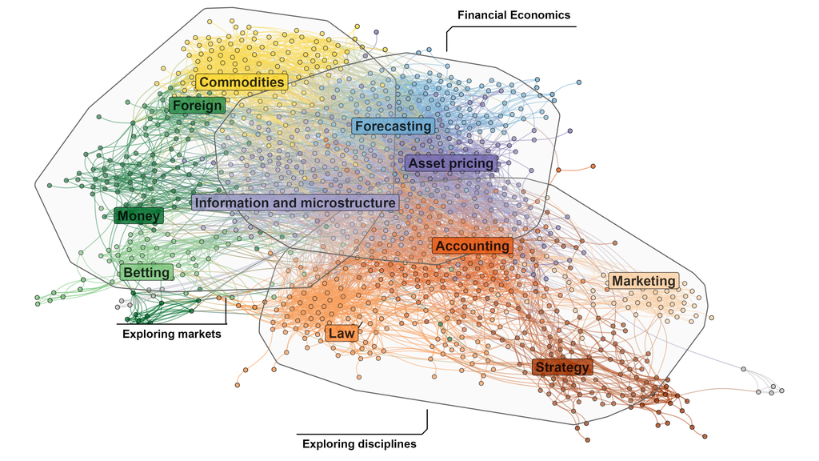

An example of a probabilistic topic model

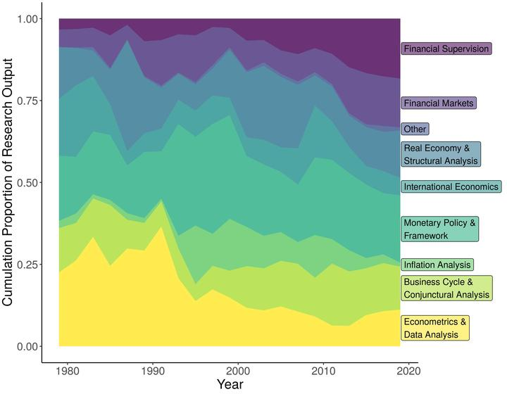

## Unsupervised Methods

**Unsupervised methods**

- A class of algorithms to identify **patterns** in unlabeled data, without predefined categories or labels as opposed to supervised methods.
- In HET, they typically served to identify clusters of documents sharing common patterns, such as similar references (bibliographic coupling) or similar vocabulary (topic modeling).
- But what do these patterns mean? Why are certain documents grouped together?
  - Requires visualisation and qualitative interpretive work to identify commonalities between observations

Qualitative and quantitative work are deeply intertwined in unsupervised methods. They are not **separate** stages, but rather a continuous back-and-forth process.

## Measuring the “Meaning” of Rationality

**Embeddings**

Embedding models represent words or sentences as vectors in a multidimensional space that captures their meaning and usage.

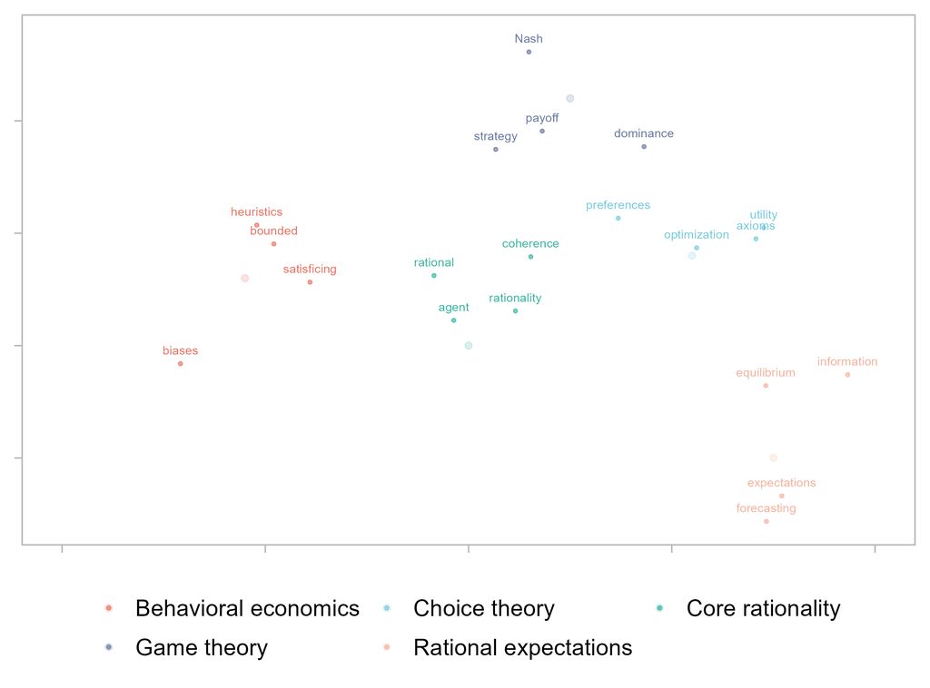

- Our goal:
  1. Use *contextual* embeddings (rather than *static*) to vectorize texts related to rationality
  2. Group these vectors into clusters (different meanings of rationality)

## Our data

- We build a corpus of 800k+ full-text documents.
- Three sources: economic journals in JSTOR, completed by Elsevier + ISTEX.
- We kept for the analysis:
  - Research articles (excluding book reviews, editorials, etc.);
  - Articles published between 1900 and 2009;
  - Articles in English.
- Resulting in a corpus of 258k+ research articles.

Not in the presentation but we also retrieve citation data to run bibliometric analyses.

Clear room for improvement: English bias, exclusion of books, etc.

## Sentence Vectors

We use *sentence-BERT*, a language model that maps **sentences** to vectors optimised for semantic similarity tasks.

Real sentences from the corpus whose vectors are close to the vector of “Economic agents are rational.”

| year | sentence | similarity |
| --- | --- | --- |
| 1950 | Rational behavior means conduct motivated by the goal of maximization of money income, wealth and economic advantages. | 0.723 |
| 1950 | One must be sensible about rationality. | 0.673 |
| 1950 | Economists are apt to insist that, for rational conduct, all bygones are bygones. | 0.668 |

Real sentences from the corpus whose vectors are close to the vector of “Economic agents are rational.”

| year | sentence | similarity |
| --- | --- | --- |
| 1950 | Rational behavior means conduct motivated by the goal of maximization of money income, wealth and economic advantages. | 0.723 |
| 1950 | One must be sensible about rationality. | 0.673 |
| 1950 | Economists are apt to insist that, for rational conduct, all bygones are bygones. | 0.668 |
| 1975 | Such agents are assumed to act rationally and exclusively on the basis of market given information. | 0.745 |
| 1975 | One premise here is that actors are rational. | 0.731 |
| 1975 | Whether expectations are rational or adaptive is another question requiring empirical investigation,*3) though it is theoretically implausible that economic agents should deliberately ignore informati… | 0.694 |

Real sentences from the corpus whose vectors are close to the vector of “Economic agents are rational.”

| year | sentence | similarity |
| --- | --- | --- |
| 1950 | Rational behavior means conduct motivated by the goal of maximization of money income, wealth and economic advantages. | 0.723 |
| 1950 | One must be sensible about rationality. | 0.673 |
| 1950 | Economists are apt to insist that, for rational conduct, all bygones are bygones. | 0.668 |
| 1975 | Such agents are assumed to act rationally and exclusively on the basis of market given information. | 0.745 |
| 1975 | One premise here is that actors are rational. | 0.731 |
| 1975 | Whether expectations are rational or adaptive is another question requiring empirical investigation,*3) though it is theoretically implausible that economic agents should deliberately ignore informati… | 0.694 |
| 2000 | Agents have rational expectations. | 0.812 |
| 2000 | Economic theory traditionally assumes rational agents. | 0.803 |
| 2000 | The ‘rational’ actor maximizing his or her profit or utility may be a convenient hypothesis for simplistic economic theories, but it bears little resemblance to the real world. | 0.777 |

## Measuring Polysemy & Semantic Evolution

Giulianelli, Tredici, and Fernández (2020), “Analysing Lexical Semantic Change with Contextualised Word Representations”

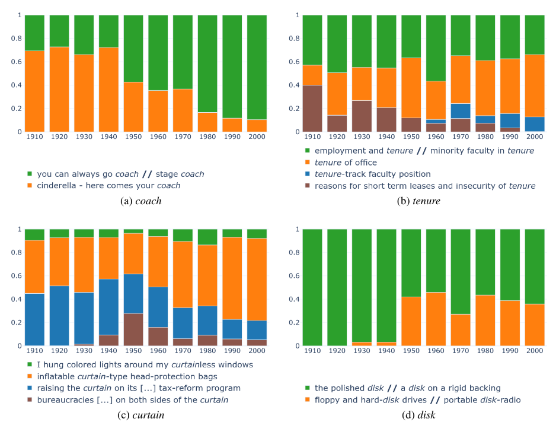

- Extract sentences using a particular word (e.g. “coach”)
- Vectorise these sentences
- Cluster these vectors
- Two issues:
  - Only explicit uses of the word are captured
  - Can’t handle bias of corpus growing over time

## Empirical Strategy

1. Vectorise the 61M sentences in the corpus using sentence-BERT.
2. Compute the “representative vectors”. *For each year*:
   1. Select all vectors of sentences containing “rational” or “rationality”;
   2. Compute the moving average of these vectors;
   3. This average vector is the “representative vector”, $RV$: it captures the meanings of rationality in a given year.
3. Extract sentences closest to these vectors. *For each year*:
   1. Compute the cosine similarity between $RV$ and the sentence vectors;
   2. Select the top 1% most similar sentences.
4. Clustering:
   1. Group sentences by decade;
   2. Group clusters across decades to identify “meta-clusters” that persist over time.

## Visualising clusters as a network

Static

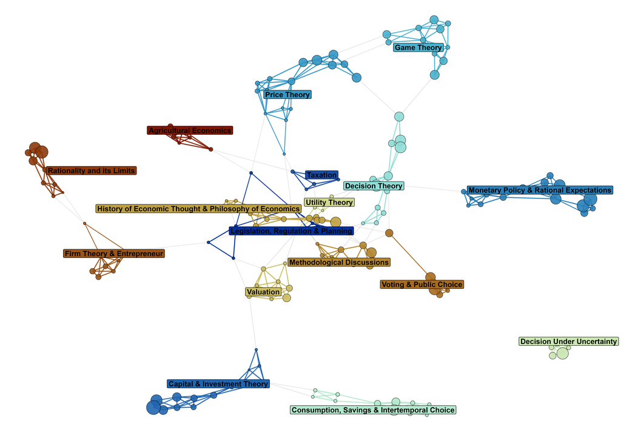

Dynamic

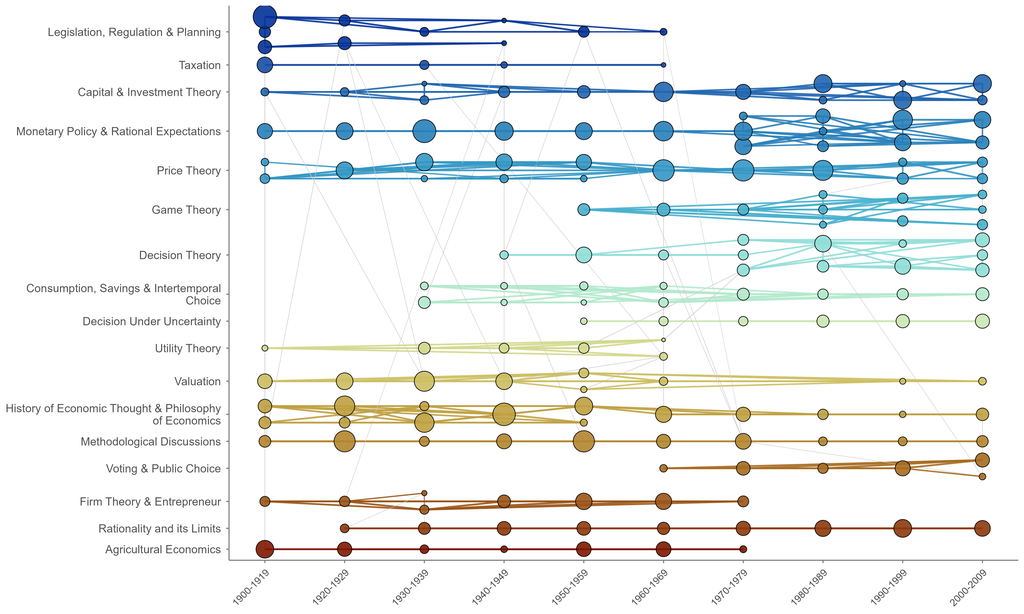

## But What Do These Clusters Correspond To?

- We need to *select* and *rank* the most relevant information to interpret these clusters.
  - Development of a set of complementary indicators:
    - Most frequent words
    - Closest sentences
    - Closest articles
    - Cited references
- How to share this information with readers and reviewers ?
  - Production of long reports with tables in the appendix but hardly readable and replicable by readers.
  - Development of an interactive application for exploring results

## Some results

- Well-known trends: decision theory, game theory, rational expectations, behavioral economics, etc.
- Trends in early periods: institutionalist economists (critique of hedonism, “pecuniary” institutions).
- Interesting overlooked trends:
  - A social dimension of rationality emerging in the 1920s with the promotion of “rationalization” of processes and institutions.
  - Discussions on entrepreneurs play an important role in the critiques of profit-maximization.

## Bibliography

Giulianelli, Mario, Marco Del Tredici, and Raquel Fernández. 2020. “Analysing Lexical Semantic Change with Contextualised Word Representations.” arXiv. https://arxiv.org/abs/2004.14118.